# 808W Assignment 3

Pranav P. Jaipurkar (115798120)

11/6/2018

Comments: # Q1: Reading the dataset

```r
qb.train <- read.csv("~/Desktop/Data Science 808W/Assignment 3/all/qb.train.csv")
View(qb.train)

qb.test <- read.csv("~/Desktop/Data Science 808W/Assignment 3/all/qb.test.csv")
View(qb.test)

qb.guess.sample <- read.csv("~/Desktop/Data Science 808W/Assignment 3/all/qb.guess-sample.csv")
View(qb.guess.sample)
```

Comments: Q2: SVM using Functions Functions

```r
library(e1071)
library(cwhmisc)
```

Comments: Creating functions

```r
model.accuracy <- function(data, name, model, test) {
  svm.pred <- predict(model, test)
  svm.table <- table(pred = svm.pred, true = test$corr)
  data <- rbind(data, data.frame(model=c(name), score=c(classAgreement(svm.table)$diag)))
  return(data)
}

paren_match <- function(page, text) {
  start <- cpos(page, "(")
  end <- cpos(page, ")")
  if (!is.na(start) && !is.na(end)) {
    search <- substring(page, start + 1, end - 1)
    return(grepl(tolower(search), tolower(text), fixed=TRUE))
  } else {
    return(FALSE)
  }
}
```

Comments: Creating some additional parameters

```r
a <- qb.train
b <- qb.test
a$obs_len <- apply(a, 1, function(x) {nchar(x['text'])})
b$obs_len <- apply(b, 1, function(x) {nchar(x['text'])})

a$scale_len <- scale(a$obs_len)
b$scale_len <- scale(b$obs_len)

a$scale_score <- scale(a$body_score)
b$scale_score <- scale(b$body_score)

a$paren_match <- apply(a, 1, function(x) {paren_match(x['page'], x['text'])})
b$paren_match <- apply(b, 1, function(x) {paren_match(x['page'], x['text'])})

a$log_links <- scale(log(as.numeric(a$inlinks) + 1))
b$log_links <- scale(log(as.numeric(b$inlinks) + 1))

index <- 1:nrow(a)
testindex <- sample(index, trunc(length(index)/5))
testset <- a[testindex,]
trainset <- a[-testindex,]
```

Comments: Get the most frequent baseline

```r
min.error <- sum(a$corr == "False") / (sum(a$corr == "False") + sum(a$corr == "True"))
min.error
```

```
## [1] 0.5542765
```

```r
models <- NULL
models <- data.frame(model=c("basic"), score=c(min.error))
```

Comments: Using the functions to make models

```r
models <- model.accuracy(models, "body_score.svm", svm(corr ~ body_score, data=trainset), testset)
models <- model.accuracy(models, "scale_score.svm", svm(corr ~ scale_score, data=trainset), testset)
models <- model.accuracy(models, "obs_len.svm", svm(corr ~ obs_len, data=trainset), testset)
models <- model.accuracy(models, "score+len.svm", svm(corr ~ obs_len + body_score, data=trainset), testset)
models <- model.accuracy(models, "paren+len.svm", svm(corr ~ obs_len + paren_match, data=trainset), testset)
models <- model.accuracy(models, "paren_match.svm", svm(corr ~ paren_match, data=trainset), testset)
models <- model.accuracy(models, "score+paren_match", svm(corr ~ scale_score + paren_match, data=trainset), testset)
models <- model.accuracy(models, "score+len+paren_match.svm", svm(corr ~ scale_len + scale_score + paren_match, data=trainset), testset)
models <- model.accuracy(models, "links.svm", svm(corr ~ inlinks, data=trainset), testset)
models <- model.accuracy(models, "loglinks.svm", svm(corr ~ log_links, data=trainset), testset)
models <- model.accuracy(models, "score+len+links+paren_match.svm", svm(corr ~ scale_len + scale_score + log_links + paren_match, data=trainset), testset)
models <- model.accuracy(models, "score+links+paren_match.svm", svm(corr ~ scale_len + scale_score + paren_match, data=trainset), testset)
View(models)
```

Comments: SVM model using different kernels

```r
a <- qb.train
b <- qb.test
a$obs_len <- apply(a, 1, function(x) {nchar(x['text'])})
b$obs_len <- apply(b, 1, function(x) {nchar(x['text'])})

a$scale_len <- scale(a$obs_len)
b$scale_len <- scale(b$obs_len)

a$scale_score <- scale(a$body_score)
b$scale_score <- scale(b$body_score)

a$paren_match <- apply(a, 1, function(x) {paren_match(x['page'], x['text'])})
b$paren_match <- apply(b, 1, function(x) {paren_match(x['page'], x['text'])})

index <- 1:nrow(a)
testindex <- sample(index, trunc(length(index)/5))
testset <- a[testindex,]
trainset <- a[-testindex,]
```

Comments: Linear Kernel

```r
svm11 <- svm(corr ~ body_score, kernel = "linear", data=a)
k11 <- predict(svm11, b)
View(k11)
l11 <- data.frame(b$row, k11)
colnames(l11) <- c("row", "corr")
View(l11)
write.csv(l11, "modelpred1.csv")

svm12 <- svm(corr ~ body_score + obs_len, kernel = "linear", data=a)
k12 <- predict(svm12, b)
View(k12)
l12 <- data.frame(b$row, k12)
colnames(l12) <- c("row", "corr")
View(l12)
write.csv(l12, "modelpred2.csv")
```

Comments: Sigmoidal Kernel

```r
svm21 <- svm(corr ~ body_score, kernel = "sigmoid", data=a)
k21 <- predict(svm21, b)
View(k21)
l21 <- data.frame(b$row, k21)
colnames(l21) <- c("row", "corr")
View(l21)
write.csv(l21, "modelpred3.csv")

svm22 <- svm(corr ~ body_score + obs_len, kernel = "sigmoid", data=a)
k22 <- predict(svm22, b)
View(k22)
l22 <- data.frame(b$row, k22)
colnames(l22) <- c("row", "corr")
View(l22)
write.csv(l22, "modelpred4.csv")
```

Comments: Polynomial Kernel

```r
svm31 <- svm(corr ~ body_score, kernel = "polynomial", data=a)
k31 <- predict(svm31, b)
View(k31)
l31 <- data.frame(b$row, k31)
colnames(l31) <- c("row", "corr")
View(l31)
write.csv(l31, "modelpred5.csv")

svm32 <- svm(corr ~ body_score, kernel = "polynomial", data=a)
k32 <- predict(svm32, b)
View(k32)
l32 <- data.frame(b$row, k32)
colnames(l32) <- c("row", "corr")
View(l32)
write.csv(l32, "modelpred6.csv")
```

Comments: SVM using default Radial Kernel

```r
svm4 <- svm(corr ~ scale_len + scale_score + paren_match, data=a)
k4 <- predict(svm4, b)
View(k4)
l4 <- data.frame(b$row, k4)
colnames(l4) <- c("row", "corr")
View(l4)
write.csv(l4, "modelpred7.csv")

svm5 <- svm(corr ~ inlinks + scale_score + paren_match, data=a)
k5 <- predict(svm5, b)
View(k5)
l5 <- data.frame(b$row, k5)
colnames(l5) <- c("row", "corr")
View(l5)
write.csv(l5, "modelpred8.csv")

svm6 <- svm(corr ~ scale_score + paren_match, data=a)
k6 <- predict(svm6, b)
View(k6)
l6 <- data.frame(b$row, k6)
colnames(l6) <- c("row", "corr")
View(l6)
write.csv(l5, "modelpred9.csv")
```

Comments: Logistic Regression

```r
a <- qb.train
b <- qb.test

index <- 1:nrow(a)
testindex <- sample(index, trunc(length(index)/5))
testset <- a[testindex,]
trainset <- a[-testindex,]
```

Comments: Making logistic regression models

```r
lr_model1 <- glm(corr ~ body_score, data = trainset, family = "binomial")
summary(lr_model1)
```

```
##
## Call:
## glm(formula = corr ~ body_score, family = "binomial", data = trainset)
##
## Deviance Residuals:
##     Min       1Q   Median       3Q      Max
## -1.7321  -1.0183  -0.8712   1.1850   1.7192
##
## Coefficients:
##              Estimate Std. Error z value Pr(>|z|)
## (Intercept) -1.218906   0.051107  -23.85   <2e-16 ***
## body_score   0.017203   0.000782   22.00   <2e-16 ***
## ---
## Signif. codes:  0 '***' 0.001 '**' 0.01 '*' 0.05 '.' 0.1 ' ' 1
##
## (Dispersion parameter for binomial family taken to be 1)
##
##     Null deviance: 8881.5  on 6463  degrees of freedom
## Residual deviance: 8278.3  on 6462  degrees of freedom
## AIC: 8282.3
##
## Number of Fisher Scoring iterations: 4
```

```r
lr_model2 <- glm(corr ~ answer_type, data = trainset, family = "binomial")
summary(lr_model2)
```

```
##
## Call:
## glm(formula = corr ~ answer_type, family = "binomial", data = trainset)
##
## Deviance Residuals:
##     Min       1Q   Median       3Q      Max
## -1.3406  -1.0382  -0.8081   1.0225   2.0631
##
## Coefficients:
##                   Estimate Std. Error z value Pr(>|z|)
## (Intercept)        -2.0015     0.4765  -4.201 2.66e-05 ***
## answer_typeanim     1.4137     0.7336   1.927 0.053964 .
## answer_typechar     1.4385     0.4953   2.905 0.003676 **
## answer_typeevent    0.4974     0.9155   0.543 0.586913
## answer_typeNone     1.0499     0.4805   2.185 0.028906 *
## answer_typeorg      0.9029     0.5741   1.573 0.115794
## answer_typepeople   1.6649     0.4782   3.481 0.000499 ***
## answer_typeplace    0.7904     0.5654   1.398 0.162167
## answer_typework     2.3774     0.4784   4.970 6.70e-07 ***
## ---
## Signif. codes:  0 '***' 0.001 '**' 0.01 '*' 0.05 '.' 0.1 ' ' 1
##
## (Dispersion parameter for binomial family taken to be 1)
##
##     Null deviance: 8881.5  on 6463  degrees of freedom
## Residual deviance: 8468.6  on 6455  degrees of freedom
## AIC: 8486.6
##
## Number of Fisher Scoring iterations: 4
```

Comments: Predicting using the logistic regression models made above

```r
lr_model1_pr <- predict(lr_model1, testset, type = "response")
lr_model1_pr <- ifelse(lr_model1_pr > 0.5, "True", "False")
View(lr_model1_pr)
lr_model2_pr <- predict(lr_model2, testset, type = "response")
lr_model2_pr <- ifelse(lr_model2_pr > 0.5, "True", "False")
View(lr_model2_pr)
```

Comments: Creating the accuracy table

```r
tb1 <- table(testset$corr, lr_model1_pr)
accuracy.glm1 <- sum(diag(tb1))/sum(tb1)
accuracy.glm1
```

```
## [1] 0.6866873
```

```r
tb2 <- table(testset$corr, lr_model2_pr)
accuracy.glm2 <- sum(diag(tb2))/sum(tb2)
accuracy.glm2
```

```
## [1] 0.6037152
```

Comments: Adding the accuracy of logistic regression model in final table

```r
glm.acc <- data.frame(model = "Logistic Regreesion", score = accuracy.glm1)
models <- rbind(models, glm.acc)
models
```

```
##                              model     score
## 1                            basic 0.5542765
## 2                   body_score.svm 0.7684211
## 3                  scale_score.svm 0.7684211
## 4                      obs_len.svm 0.5492260
## 5                    score+len.svm 0.8198142
## 6                    paren+len.svm 0.5653251
## 7                  paren_match.svm 0.5653251
## 8                score+paren_match 0.7671827
## 9        score+len+paren_match.svm 0.8142415
## 10                       links.svm 0.5492260
## 11                    loglinks.svm 0.6160991
## 12 score+len+links+paren_match.svm 0.8204334
## 13     score+links+paren_match.svm 0.8142415
## 14             Logistic Regreesion 0.6866873
```

Comments: Correlation and Correlation Plots

```r
a$corr <- ifelse(a$corr == "True", 1, 0)
cor(a[, c(-1, -3, -4, -5, -6, -7, -8, -10)])
```

```
##            body_score      corr
## body_score  1.0000000 0.3001621
## corr        0.3001621 1.0000000
```

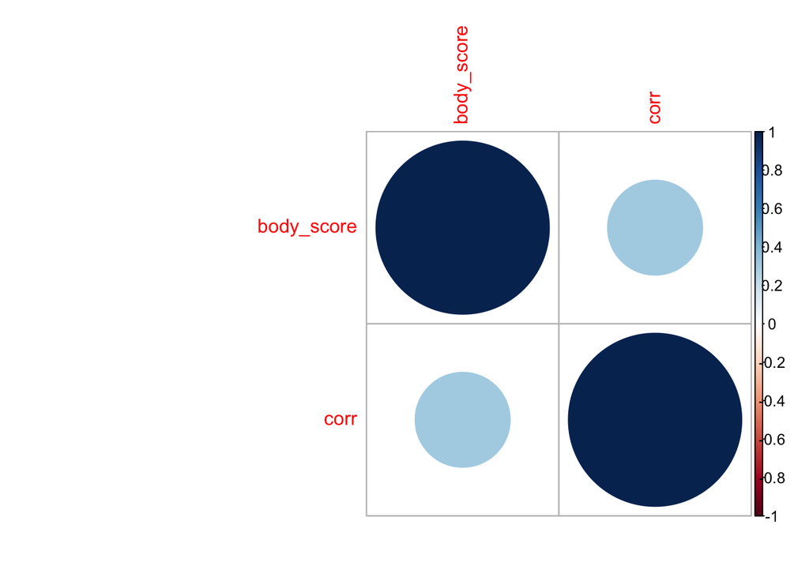

```r
library(corrplot)
corrplot(cor(a[, c(-1, -3, -4, -5, -6, -7, -8, -10)]))
```

Comments: Decision tree Tree Library

```r
a <- qb.train
b <- qb.test
a$corr <- ifelse(a$corr == "True", 1, 0)
levels(b$body_score) <- union(levels(a$body_score), levels(b$body_score))
index <- 1:nrow(a)
testindex <- sample(index, trunc(length(index)/5))
testset <- a[testindex,]
trainset <- a[-testindex,]
```

Comments: Using tree library

```r
library(tree)
dt.model <- tree(corr ~ body_score, data = trainset)
summary(dt.model)
```

```
##
## Regression tree:
## tree(formula = corr ~ body_score, data = trainset)
## Number of terminal nodes:  4
## Residual mean deviance:  0.1704 = 1101 / 6460
## Distribution of residuals:
##     Min.  1st Qu.   Median     Mean  3rd Qu.     Max.
## -0.93170 -0.26540 -0.26540  0.00000  0.09545  0.73460
```

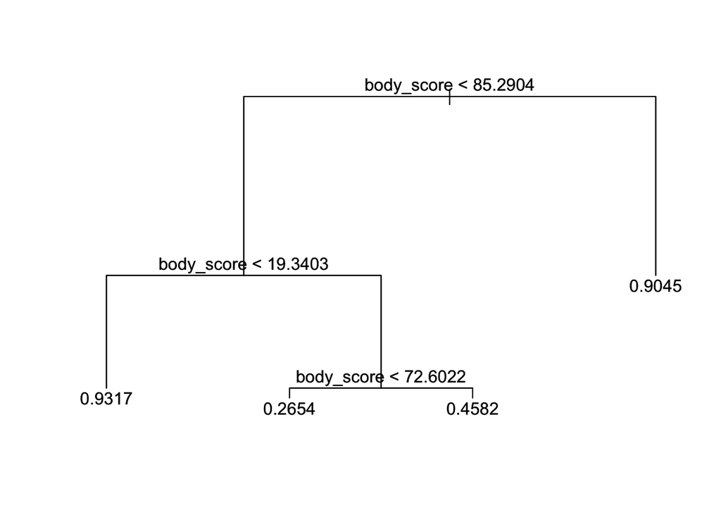

```r
plot(dt.model, main = "Decision Tree Model")
text(dt.model)
text(dt.model, pretty = 5, cex = 1)
```

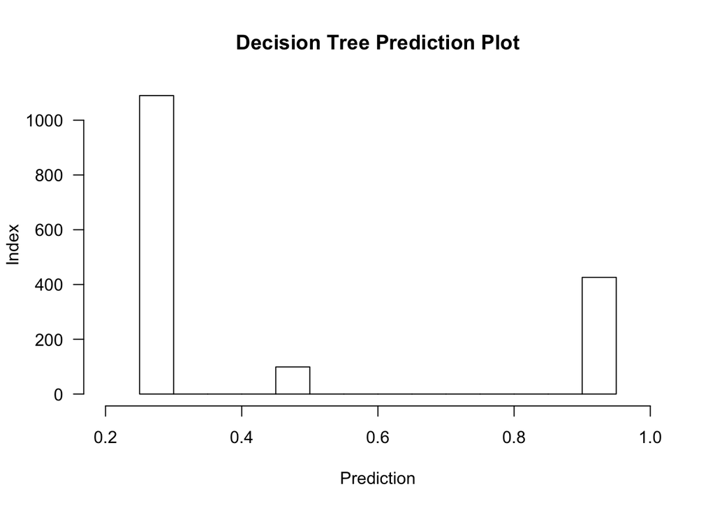

```r
dt.model.pred <- predict(dt.model, newdata = testset)
hist(dt.model.pred, main = "Decision Tree Prediction Plot", xlab ="Prediction", ylab = "Index", xlim = c(0.2, 1), las = 1)
```

```r
dt.model.pred <- ifelse(dt.model.pred > 0.5, "True", "False")
View(dt.model.pred)
head(dt.model.pred, n = 5)
```

```
##    3029    8003    3077    1272    7456
## "False" "False"  "True" "False" "False"
```

```r
dt.model.a <- tree(corr ~ body_score, data = a)
dt.model.pred.a <- predict(dt.model, newdata = b)
h1 <- data.frame(b$row, dt.model.pred.a)
colnames(h1) <- c("row", "corr")
h1$corr <- ifelse(h1$corr > 0.5, "True", "False")
View(h1)
write.csv(h1, "modelpred10.csv")
```

Comments: Party Library

```r
a <- qb.train
b <- qb.test
library(party)
party.tree1 <- ctree(corr ~ body_score, data = trainset, controls = ctree_control(mincriterion = 0.95, minsplit = 1000))
party.tree1
```

```
##
##   Conditional inference tree with 6 terminal nodes
##
## Response:  corr
## Input:  body_score
## Number of observations:  6464
##
## 1) body_score <= 85.2685; criterion = 1, statistic = 608.08
##   2) body_score <= 19.3244; criterion = 1, statistic = 150.08
##     3)*  weights = 483
##   2) body_score > 19.3244
##     4) body_score <= 72.5981; criterion = 1, statistic = 14.605
##       5) body_score <= 21.52559; criterion = 0.961, statistic = 4.259
##         6)*  weights = 137
##       5) body_score > 21.52559
##         7)*  weights = 4245
##     4) body_score > 72.5981
##       8)*  weights = 478
## 1) body_score > 85.2685
##   9) body_score <= 108.5293; criterion = 1, statistic = 73.878
##     10)*  weights = 409
##   9) body_score > 108.5293
##     11)*  weights = 712
```

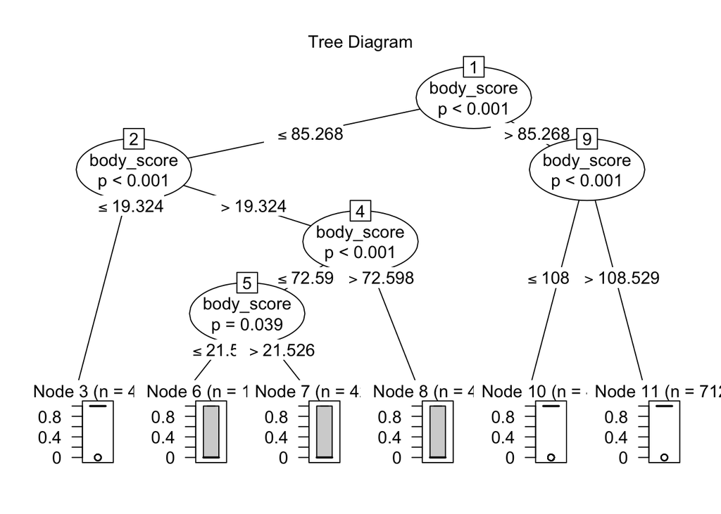

```r
plot(party.tree1, main = "Tree Diagram")
```

```r
party.tree2 <- ctree(corr ~ body_score + inlinks, data = trainset, controls = ctree_control(mincriterion = 0.95, minsplit = 2500))
party.tree2
```

```
##
##   Conditional inference tree with 6 terminal nodes
##
## Response:  corr
## Inputs:  body_score, inlinks
## Number of observations:  6464
##
## 1) body_score <= 85.2685; criterion = 1, statistic = 608.08
##   2) body_score <= 19.3244; criterion = 1, statistic = 150.08
##     3)*  weights = 483
##   2) body_score > 19.3244
##     4) body_score <= 72.5981; criterion = 1, statistic = 14.605
##       5) inlinks <= 11; criterion = 0.961, statistic = 5.446
##         6)*  weights = 1814
##       5) inlinks > 11
##         7) body_score <= 22.33999; criterion = 1, statistic = 20.974
##           8)*  weights = 73
##         7) body_score > 22.33999
##           9)*  weights = 2495
##     4) body_score > 72.5981
##       10)*  weights = 478
## 1) body_score > 85.2685
##   11)*  weights = 1121
```

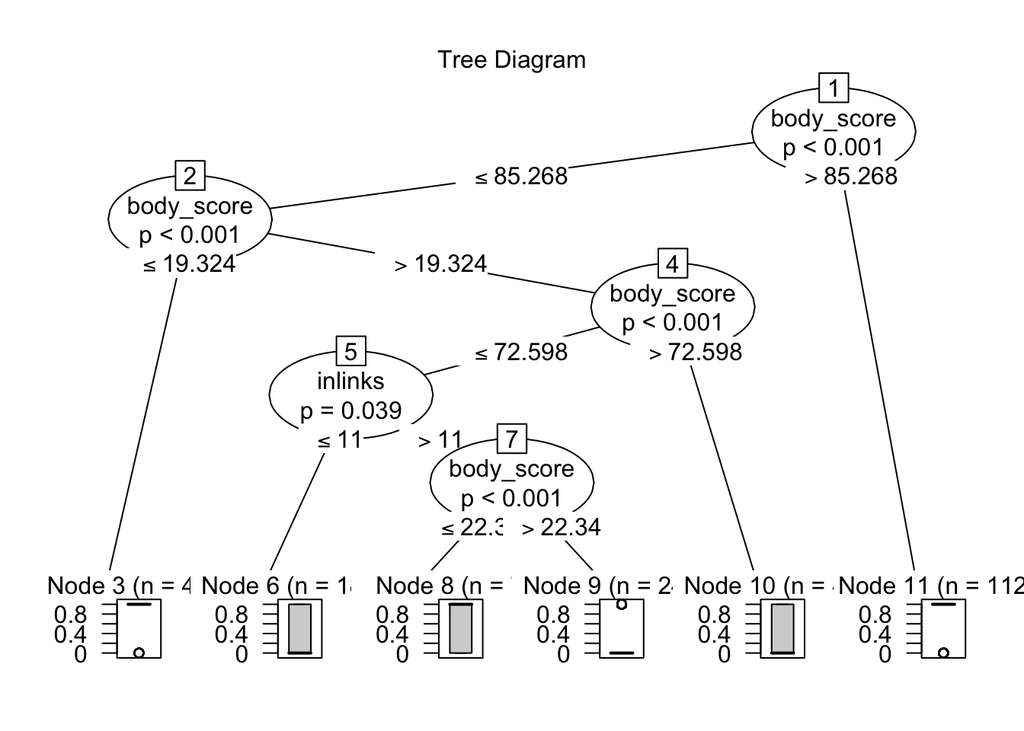

```r
plot(party.tree2, main = "Tree Diagram")
```

```r
party.tree.pred11 <- predict(party.tree1, testset, type = "response")
View(party.tree.pred11)
party.tree.pred12 <- predict(party.tree2, testset, type = "response")
View(party.tree.pred12)

ty1 <- table(party.tree.pred11, testset$corr)
ty2 <- table(party.tree.pred12, testset$corr)

acc.rpart1 <- sum(diag(ty1))/sum(ty1)
acc.rpart1
```

```
## [1] 0.5077399
```

```r
acc.rpart2 <- sum(diag(ty2))/sum(ty2)
acc.rpart2
```

```
## [1] 0.4321981
```

Comments: Decision Tree using rpart library

```r
a <- qb.train
b <- qb.test
a$corr <- ifelse(a$corr == "True", 1, 0)

index <- 1:nrow(a)
testindex <- sample(index, trunc(length(index)/5))
testset <- a[testindex,]
trainset <- a[-testindex,]
```

Comments: Rpart decision tree models

```r
library(rpart)
library(rpart.plot)
rpart_tree1 <- rpart(corr ~ body_score, data = trainset)
View(rpart_tree1)
```

```
## Error in as.data.frame.default(x): cannot coerce class '"rpart"' to a data.frame
```

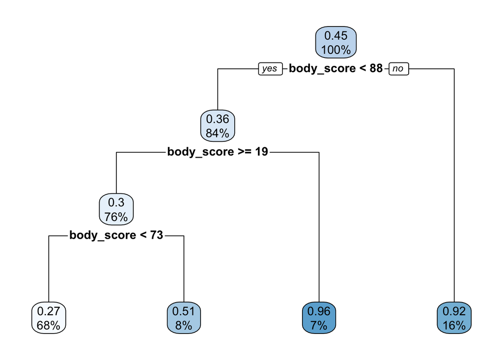

```r
rpart.plot(rpart_tree1)
```

```r
rpart_tree2 <- rpart(corr ~ body_score + inlinks, data = trainset)
View(rpart_tree2)
```

```
## Error in as.data.frame.default(x): cannot coerce class '"rpart"' to a data.frame
```

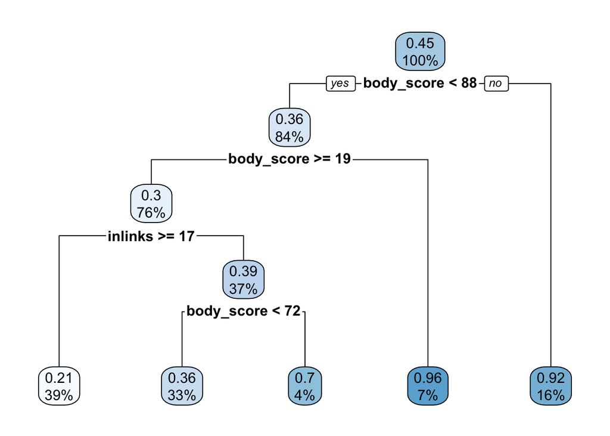

```r
rpart.plot(rpart_tree2)
```

Comments: Prediction

```r
rpart_tree_pred1 <- predict(rpart_tree1, testset)
rpart_tree_pred1 <- ifelse(rpart_tree_pred1 > 0.5, "True", "False")
View(rpart_tree_pred1)
rpart_tree_pred2 <- predict(rpart_tree2, testset)
rpart_tree_pred2 <- ifelse(rpart_tree_pred2 > 0.5, "True", "False")
View(rpart_tree_pred2)
```

Comments: Creating the accuracy table

```r
tab <- table(rpart_tree_pred1, testset$corr)
print(tab)
```

```
##
## rpart_tree_pred1   0   1
##            False 811 306
##            True  102 396
```

```r
accuracy_dt <- sum(diag(tab))/sum(tab)
accuracy_dt
```

```
## [1] 0.7473684
```

```r
dt_acc <- data.frame(model = "Decision_tree", score = accuracy_dt)
dt_acc
```

```
##           model     score
## 1 Decision_tree 0.7473684
```

Comments: Accuracy Table

```r
final_acc <- rbind(models, dt_acc)
final_acc
```

```
##                              model     score
## 1                            basic 0.5542765
## 2                   body_score.svm 0.7684211
## 3                  scale_score.svm 0.7684211
## 4                      obs_len.svm 0.5492260
## 5                    score+len.svm 0.8198142
## 6                    paren+len.svm 0.5653251
## 7                  paren_match.svm 0.5653251
## 8                score+paren_match 0.7671827
## 9        score+len+paren_match.svm 0.8142415
## 10                       links.svm 0.5492260
## 11                    loglinks.svm 0.6160991
## 12 score+len+links+paren_match.svm 0.8204334
## 13     score+links+paren_match.svm 0.8142415
## 14             Logistic Regreesion 0.6866873
## 15                   Decision_tree 0.7473684
```

Comments: Q3:

```r
a <- qb.train
b <- qb.test
levels(a$answer_type)
```

```
## [1] "abs"    "anim"   "char"   "event"  "None"   "org"    "people" "place"
## [9] "work"
```

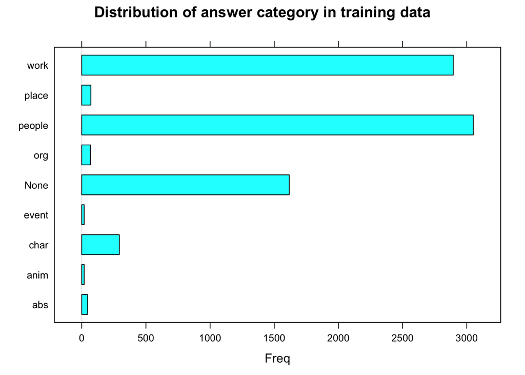

```r
barchart(a$answer_type, main = "Distribution of answer category in training data")
```

Comments: Making subset for work and people answer category

```r
c <- a[a$answer_type == "work", ]
View(c)
d <- a[a$answer_type == "people", ]
View(d)
levels(b$answer_type)
```

```
## [1] "abs"    "anim"   "char"   "event"  "None"   "org"    "people" "place"
## [9] "work"
```

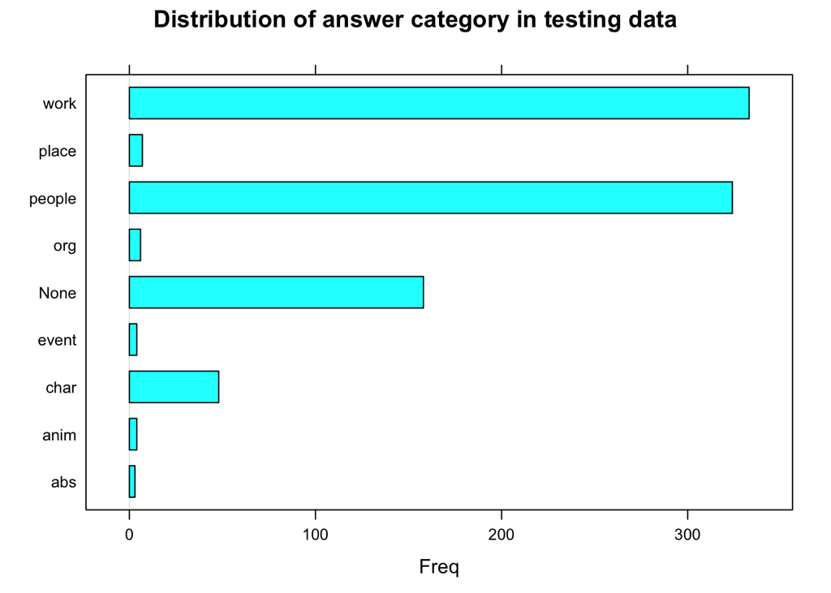

```r
barchart(b$answer_type, main = "Distribution of answer category in testing data")
```

```r
e <- b[b$answer_type == "work", ]
View(e)
f <- b[b$answer_type == "people", ]
View(f)

index.work <- 1:nrow(c)
testindex.work <- sample(index.work, trunc(length(index.work)/5))
testset.work <- c[testindex.work,]
trainset.work <- c[-testindex.work,]

index.peop <- 1:nrow(d)
testindex.peop <- sample(index.peop, trunc(length(index.peop)/5))
testset.peop <- d[testindex.peop,]
trainset.peop <- d[-testindex.peop,]

trainset.work$obs_len <- apply(trainset.work, 1, function(x) {nchar(x['text'])})
trainset.peop$obs_len <- apply(trainset.peop, 1, function(x) {nchar(x['text'])})
testset.work$obs_len <- apply(testset.work, 1, function(x) {nchar(x['text'])})
testset.peop$obs_len <- apply(testset.peop, 1, function(x) {nchar(x['text'])})

models.work <- svm(corr ~ obs_len + body_score, data=trainset.work)
models.peop <- svm(corr ~ obs_len + body_score, data=trainset.peop)
w1 <- predict(models.work, testset.work)
p1 <- predict(models.peop, testset.peop)
t1 <- table(w1, testset.work$corr)
a1 <- sum(diag(t1))/sum(t1)
t2 <- table(p1, testset.peop$corr)
a2 <- sum(diag(t2))/sum(t2)
a1
```

```
## [1] 0.8134715
```

```r
a2
```

```
## [1] 0.7557377
```

[figure not shown]

```r
plot(a1, ylim = c(0.76, 0.81), main = "Accuracy Comparision Plot", pch = 1, col = 2, ylab = "Accuracy", las = 1)
points(a2, pch = 1, col = 3)
points(models$score[models$model == "score+len.svm"], pch = 1, col = 4)
legend(x = "topright",legend = c("Work_SVM", "People_SVM", "General_SVM"), pch = c(1, 1, 1), col = c(2, 3, 4))
```

Comments: Q4: Creating an object with row_ID, predicted corr and true corr

```r
error_analysis <- data.frame(testset.work$row, w1, testset.work$corr)
View(error_analysis)
```

Comments: Creating an object with misclassifications

```r
errors <- error_analysis[w1 != testset.work$corr, ]
View(errors)
```

```r
v1 <- testset.work[, c("row","obs_len", "body_score")]
View(v1)
```

Comments: Summarizing columns of v1

```r
summary(v1$obs_len)
```

```
##    Min. 1st Qu.  Median    Mean 3rd Qu.    Max.
##    32.0   239.5   423.0   425.8   586.0  1107.0
```

```r
summary(v1$body_score)
```

```
##    Min. 1st Qu.  Median    Mean 3rd Qu.    Max.
##    2.26   32.35   53.07   69.42   92.58  359.08
```